# TraceBase PeakGroup Plots

This notebook provides a simple example of how one can create barplots easily from PeakGroup data exported from TraceBase.

First, we load our required libraries.

```r
# Load required libraries
library(readr, quietly = TRUE)
library(stringr, quietly = TRUE)
library(ggplot2, quietly = TRUE)
library(Rmisc, quietly = TRUE)
library(dplyr, quietly = TRUE, warn.conflicts = FALSE)
```

## Serine Labeling from Serine Synthesis Study

### Load PeakGroup data

The PeakGroup data was downloaded from TraceBase by:

1. View a specific study^
2. Click the “PeakGroup Data” link at the top
3. Click on the “Export Data” button

^ The study data used in this example (Serine synthesis from glucose in control vs ser/gly-free diet) is not publicly available, but by following this example, you can apply a similar analysis to any of the [Studies](https://tracebase.princeton.edu/DataRepo/studies/) available on tracebase.princeton.edu.

```r
serinesyn_peakgroup_data_table <-
  "data/serine_synthesis/PeakGroups_10.02.2023.16.17.17.tsv"
serinesyn_peakgroup_data <-
  readr::read_tsv(serinesyn_peakgroup_data_table,
    comment = "#", na = c("None")
  )
serinesyn_peakgroup_data
```

| Sample | Tissue | Time Collected (m) | Peak Group | Measured Compound(s) | Measured Compound Synonym(s) | Formula | Labeled Element | Total Abundance | Enrichment Fraction | Enrichment Abundance | Normalized Labeling | Peak Group Set Filename | Animal | Genotype | Body Weight (g) | Age (weeks) | Sex | Diet | Feeding Status | Treatment | Infusate | Tracer(s) | Tracer Compound(s) | Tracer Concentration(s) | Infusion Rate (ul/min/g) | Studies |
| --- | --- | --- | --- | --- | --- | --- | --- | --- | --- | --- | --- | --- | --- | --- | --- | --- | --- | --- | --- | --- | --- | --- | --- | --- | --- | --- |
| 072920_M1_1_TS1 | serum_plasma_unspecified_location | 150 | glucose | glucose | D-Glucose/glucose/dextrose | C6H12O6 | C | 36013239.45 | 1.931068e-01 | 6.954400e+06 | 1.000000000 | 072920_M1_corrected.xlsx | 072920_M1 | C57BL/6 | 28.4 | NA | M | TestDiet 5WTV_Purified Amino Acid Control Diet | fasted | no treatment | glucose-[13C6][200] | glucose-[13C6] | glucose | 200 | 0.1 | Serine synthesis from glucose in control vs ser/gly-free diet |
| 072920_M1_2_bra | brain | 150 | glucose | glucose | D-Glucose/glucose/dextrose | C6H12O6 | C | 263041.40 | 1.263458e-01 | 3.323416e+04 | 0.654279228 | 072920_M1_corrected.xlsx | 072920_M1 | C57BL/6 | 28.4 | NA | M | TestDiet 5WTV_Purified Amino Acid Control Diet | fasted | no treatment | glucose-[13C6][200] | glucose-[13C6] | glucose | 200 | 0.1 | Serine synthesis from glucose in control vs ser/gly-free diet |
| 072920_M1_3_quad | quadricep | 150 | glucose | glucose | D-Glucose/glucose/dextrose | C6H12O6 | C | 1966948.11 | 1.388479e-01 | 2.731065e+05 | 0.719021197 | 072920_M1_corrected.xlsx | 072920_M1 | C57BL/6 | 28.4 | NA | M | TestDiet 5WTV_Purified Amino Acid Control Diet | fasted | no treatment | glucose-[13C6][200] | glucose-[13C6] | glucose | 200 | 0.1 | Serine synthesis from glucose in control vs ser/gly-free diet |
| 072920_M1_4_kid | kidney | 150 | glucose | glucose | D-Glucose/glucose/dextrose | C6H12O6 | C | 17118647.56 | 1.440563e-01 | 2.466050e+06 | 0.745993159 | 072920_M1_corrected.xlsx | 072920_M1 | C57BL/6 | 28.4 | NA | M | TestDiet 5WTV_Purified Amino Acid Control Diet | fasted | no treatment | glucose-[13C6][200] | glucose-[13C6] | glucose | 200 | 0.1 | Serine synthesis from glucose in control vs ser/gly-free diet |
| 072920_M1_5_liv | liver | 150 | glucose | glucose | D-Glucose/glucose/dextrose | C6H12O6 | C | 53146746.93 | 6.285682e-02 | 3.340636e+06 | 0.325502933 | 072920_M1_corrected.xlsx | 072920_M1 | C57BL/6 | 28.4 | NA | M | TestDiet 5WTV_Purified Amino Acid Control Diet | fasted | no treatment | glucose-[13C6][200] | glucose-[13C6] | glucose | 200 | 0.1 | Serine synthesis from glucose in control vs ser/gly-free diet |
| 072920_M1_6_spl | spleen | 150 | glucose | glucose | D-Glucose/glucose/dextrose | C6H12O6 | C | 3240133.51 | 1.578971e-01 | 5.116076e+05 | 0.817667220 | 072920_M1_corrected.xlsx | 072920_M1 | C57BL/6 | 28.4 | NA | M | TestDiet 5WTV_Purified Amino Acid Control Diet | fasted | no treatment | glucose-[13C6][200] | glucose-[13C6] | glucose | 200 | 0.1 | Serine synthesis from glucose in control vs ser/gly-free diet |
| 072920_M1_7_panc | pancreas | 150 | glucose | glucose | D-Glucose/glucose/dextrose | C6H12O6 | C | 3233374.41 | 1.600437e-01 | 5.174811e+05 | 0.828783365 | 072920_M1_corrected.xlsx | 072920_M1 | C57BL/6 | 28.4 | NA | M | TestDiet 5WTV_Purified Amino Acid Control Diet | fasted | no treatment | glucose-[13C6][200] | glucose-[13C6] | glucose | 200 | 0.1 | Serine synthesis from glucose in control vs ser/gly-free diet |
| 072920_M1_8_stom | stomach | 150 | glucose | glucose | D-Glucose/glucose/dextrose | C6H12O6 | C | 5170530.03 | 1.586140e-01 | 8.201185e+05 | 0.821379802 | 072920_M1_corrected.xlsx | 072920_M1 | C57BL/6 | 28.4 | NA | M | TestDiet 5WTV_Purified Amino Acid Control Diet | fasted | no treatment | glucose-[13C6][200] | glucose-[13C6] | glucose | 200 | 0.1 | Serine synthesis from glucose in control vs ser/gly-free diet |
| 072920_M1_9_lung | lung | 150 | glucose | glucose | D-Glucose/glucose/dextrose | C6H12O6 | C | 12221763.57 | 1.830131e-01 | 2.236742e+06 | 0.947729931 | 072920_M1_corrected.xlsx | 072920_M1 | C57BL/6 | 28.4 | NA | M | TestDiet 5WTV_Purified Amino Acid Control Diet | fasted | no treatment | glucose-[13C6][200] | glucose-[13C6] | glucose | 200 | 0.1 | Serine synthesis from glucose in control vs ser/gly-free diet |
| 072920_M1_10_hea | heart | 150 | glucose | glucose | D-Glucose/glucose/dextrose | C6H12O6 | C | 3901262.66 | 3.440585e-01 | 1.342262e+06 | 1.781700617 | 072920_M1_corrected.xlsx | 072920_M1 | C57BL/6 | 28.4 | NA | M | TestDiet 5WTV_Purified Amino Acid Control Diet | fasted | no treatment | glucose-[13C6][200] | glucose-[13C6] | glucose | 200 | 0.1 | Serine synthesis from glucose in control vs ser/gly-free diet |

[output cut: 551 more lines]

#### Select data

Select those rows that used a `glucose` tracer and measured `serine`.

```r
# Select columns
serinesyn_plot_data <-
  serinesyn_peakgroup_data %>%
  filter(
    str_detect(`Infusate`, "glucose-"),
    `Measured Compound(s)` == "serine"
  )
serinesyn_plot_data
```

| Sample | Tissue | Time Collected (m) | Peak Group | Measured Compound(s) | Measured Compound Synonym(s) | Formula | Labeled Element | Total Abundance | Enrichment Fraction | Enrichment Abundance | Normalized Labeling | Peak Group Set Filename | Animal | Genotype | Body Weight (g) | Age (weeks) | Sex | Diet | Feeding Status | Treatment | Infusate | Tracer(s) | Tracer Compound(s) | Tracer Concentration(s) | Infusion Rate (ul/min/g) | Studies |
| --- | --- | --- | --- | --- | --- | --- | --- | --- | --- | --- | --- | --- | --- | --- | --- | --- | --- | --- | --- | --- | --- | --- | --- | --- | --- | --- |
| 072920_M1_1_TS1 | serum_plasma_unspecified_location | 150 | serine | serine | serine/ser | C3H7NO3 | C | 124691.87 | 0.0010515201 | 131.1160 | 0.005445278 | 072920_M1_corrected.xlsx | 072920_M1 | C57BL/6 | 28.4 | NA | M | TestDiet 5WTV_Purified Amino Acid Control Diet | fasted | no treatment | glucose-[13C6][200] | glucose-[13C6] | glucose | 200 | 0.1 | Serine synthesis from glucose in control vs ser/gly-free diet |
| 072920_M1_2_bra | brain | 150 | serine | serine | serine/ser | C3H7NO3 | C | 2143529.98 | 0.0158012309 | 33870.4120 | 0.081826394 | 072920_M1_corrected.xlsx | 072920_M1 | C57BL/6 | 28.4 | NA | M | TestDiet 5WTV_Purified Amino Acid Control Diet | fasted | no treatment | glucose-[13C6][200] | glucose-[13C6] | glucose | 200 | 0.1 | Serine synthesis from glucose in control vs ser/gly-free diet |
| 072920_M1_3_quad | quadricep | 150 | serine | serine | serine/ser | C3H7NO3 | C | 1112265.64 | 0.0010308355 | 1146.5629 | 0.005338163 | 072920_M1_corrected.xlsx | 072920_M1 | C57BL/6 | 28.4 | NA | M | TestDiet 5WTV_Purified Amino Acid Control Diet | fasted | no treatment | glucose-[13C6][200] | glucose-[13C6] | glucose | 200 | 0.1 | Serine synthesis from glucose in control vs ser/gly-free diet |
| 072920_M1_4_kid | kidney | 150 | serine | serine | serine/ser | C3H7NO3 | C | 593317.14 | 0.0000000000 | 0.0000 | 0.000000000 | 072920_M1_corrected.xlsx | 072920_M1 | C57BL/6 | 28.4 | NA | M | TestDiet 5WTV_Purified Amino Acid Control Diet | fasted | no treatment | glucose-[13C6][200] | glucose-[13C6] | glucose | 200 | 0.1 | Serine synthesis from glucose in control vs ser/gly-free diet |
| 072920_M1_5_liv | liver | 150 | serine | serine | serine/ser | C3H7NO3 | C | 484607.76 | 0.0000000000 | 0.0000 | 0.000000000 | 072920_M1_corrected.xlsx | 072920_M1 | C57BL/6 | 28.4 | NA | M | TestDiet 5WTV_Purified Amino Acid Control Diet | fasted | no treatment | glucose-[13C6][200] | glucose-[13C6] | glucose | 200 | 0.1 | Serine synthesis from glucose in control vs ser/gly-free diet |
| 072920_M1_6_spl | spleen | 150 | serine | serine | serine/ser | C3H7NO3 | C | 350913.62 | 0.0034111757 | 1197.0280 | 0.017664713 | 072920_M1_corrected.xlsx | 072920_M1 | C57BL/6 | 28.4 | NA | M | TestDiet 5WTV_Purified Amino Acid Control Diet | fasted | no treatment | glucose-[13C6][200] | glucose-[13C6] | glucose | 200 | 0.1 | Serine synthesis from glucose in control vs ser/gly-free diet |
| 072920_M1_7_panc | pancreas | 150 | serine | serine | serine/ser | C3H7NO3 | C | 1013099.29 | 0.0065499989 | 6635.7993 | 0.033919053 | 072920_M1_corrected.xlsx | 072920_M1 | C57BL/6 | 28.4 | NA | M | TestDiet 5WTV_Purified Amino Acid Control Diet | fasted | no treatment | glucose-[13C6][200] | glucose-[13C6] | glucose | 200 | 0.1 | Serine synthesis from glucose in control vs ser/gly-free diet |
| 072920_M1_8_stom | stomach | 150 | serine | serine | serine/ser | C3H7NO3 | C | 1021367.67 | 0.0005409636 | 552.5227 | 0.002801370 | 072920_M1_corrected.xlsx | 072920_M1 | C57BL/6 | 28.4 | NA | M | TestDiet 5WTV_Purified Amino Acid Control Diet | fasted | no treatment | glucose-[13C6][200] | glucose-[13C6] | glucose | 200 | 0.1 | Serine synthesis from glucose in control vs ser/gly-free diet |
| 072920_M1_9_lung | lung | 150 | serine | serine | serine/ser | C3H7NO3 | C | 531222.02 | 0.0046655139 | 2478.4237 | 0.024160281 | 072920_M1_corrected.xlsx | 072920_M1 | C57BL/6 | 28.4 | NA | M | TestDiet 5WTV_Purified Amino Acid Control Diet | fasted | no treatment | glucose-[13C6][200] | glucose-[13C6] | glucose | 200 | 0.1 | Serine synthesis from glucose in control vs ser/gly-free diet |
| 072920_M1_10_hea | heart | 150 | serine | serine | serine/ser | C3H7NO3 | C | 517197.97 | 0.0021559884 | 1115.0728 | 0.011164748 | 072920_M1_corrected.xlsx | 072920_M1 | C57BL/6 | 28.4 | NA | M | TestDiet 5WTV_Purified Amino Acid Control Diet | fasted | no treatment | glucose-[13C6][200] | glucose-[13C6] | glucose | 200 | 0.1 | Serine synthesis from glucose in control vs ser/gly-free diet |

[output cut: 177 more lines]

#### Calculate summary statistics

We use the `summarySE` function to calculate the standard error for each group.

```r
serinesyn_summary_data <- serinesyn_plot_data %>%
  Rmisc::summarySE(
    measurevar = "Normalized Labeling",
    groupvars = c("`Feeding Status`", "Tissue"),
    na.rm = TRUE
  )
serinesyn_summary_data
```

| Feeding Status | Tissue | N | Normalized Labeling | sd | se | ci |
| --- | --- | --- | --- | --- | --- | --- |
| fasted | brain | 4 | 0.17594875 | 0.065524645 | 0.032762322 | 0.104264332 |
| fasted | brown_adipose_tissue | 4 | 0.04248859 | 0.008835532 | 0.004417766 | 0.014059303 |
| fasted | ear | 4 | 0.02866319 | 0.012766791 | 0.006383396 | 0.020314814 |
| fasted | heart | 4 | 0.02646268 | 0.020177438 | 0.010088719 | 0.032106807 |
| fasted | kidney | 4 | 0.02844723 | 0.019698943 | 0.009849471 | 0.031345413 |
| fasted | liver | 4 | 0.01147130 | 0.011768656 | 0.005884328 | 0.018726557 |
| fasted | lung | 4 | 0.03910143 | 0.019663334 | 0.009831667 | 0.031288752 |
| fasted | pancreas | 4 | 0.06702381 | 0.030376054 | 0.015188027 | 0.048335081 |
| fasted | quadricep | 4 | 0.02844351 | 0.019284905 | 0.009642452 | 0.030686587 |
| fasted | serum_plasma_unspecified_location | 7 | 0.05901971 | 0.063949110 | 0.024170491 | 0.059143062 |

[output cut: 20 more lines]

#### Generate the bar plot

Now we setup the plotting parameters.

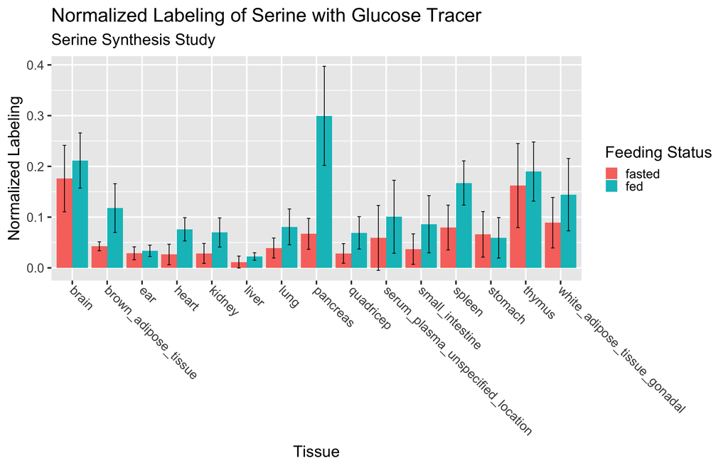

```r
# Setup the plot
p <- ggplot(
  data = serinesyn_summary_data,
  aes(x = `Tissue`, y = `Normalized Labeling`, fill = `Feeding Status`)
) +
  geom_bar(stat = "identity", position = "dodge") +
  geom_errorbar(aes(
    ymin = `Normalized Labeling` - sd,
    ymax = `Normalized Labeling` + sd
  ),
  width = .2,
  position = position_dodge(0.9)
  ) +
  theme_gray(base_size = 22) +
  theme(axis.text.x = element_text(angle = -45, vjust = 0.5, hjust = 0)) +
  ggtitle("Normalized Labeling of Serine with Glucose Tracer",
    subtitle = "Serine Synthesis Study"
  )

# Display the plot
p
```

## Serine Labeling from Multiple Studies

### Load PeakGroup data

The PeakGroup data was downloaded from TraceBase by searching with: * Output Format == “PeakGroups” * Mesured Compound == “serine” * Tracer Compound == “glucose”

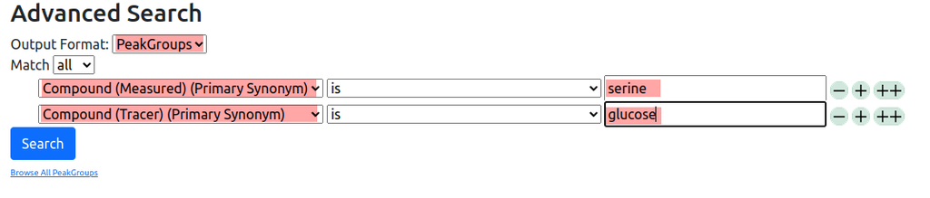

TraceBase Serine PeakGroups with Glucose Tracer

```r
all_serine_peakgroup_table <-
  "data/PeakGroups-serine-all-studies10.02.2023.16.21.50.tsv"
all_serine_peakgroup_data <-
  readr::read_tsv(all_serine_peakgroup_table, comment = "#", na = c("None"))
all_serine_peakgroup_data
```

| Sample | Tissue | Time Collected (m) | Peak Group | Measured Compound(s) | Measured Compound Synonym(s) | Formula | Labeled Element | Total Abundance | Enrichment Fraction | Enrichment Abundance | Normalized Labeling | Peak Group Set Filename | Animal | Genotype | Body Weight (g) | Age (weeks) | Sex | Diet | Feeding Status | Treatment | Infusate | Tracer(s) | Tracer Compound(s) | Tracer Concentration(s) | Infusion Rate (ul/min/g) | Studies |
| --- | --- | --- | --- | --- | --- | --- | --- | --- | --- | --- | --- | --- | --- | --- | --- | --- | --- | --- | --- | --- | --- | --- | --- | --- | --- | --- |
| xz933-t | serum_plasma_tail | 150 | serine | serine | serine/ser | C3H7NO3 | C | 343347.995 | 1.096498e-02 | 3764.8046 | 0.0357984752 | glucfasted_corrected.xlsx | xz933 | wildtype | 27.5 | 14 | M | PicoLab Rodent 20 5053 | fasted | no treatment | glucose-[13C6][300] | glucose-[13C6] | glucose | 300 | 0.109 | ob/ob Fasted |
| xz933-bat | brown_adipose_tissue | 150 | serine | serine | serine/ser | C3H7NO3 | C | 1397217.851 | 7.208786e-03 | 10072.2450 | 0.0235352468 | glucfasted_corrected.xlsx | xz933 | wildtype | 27.5 | 14 | M | PicoLab Rodent 20 5053 | fasted | no treatment | glucose-[13C6][300] | glucose-[13C6] | glucose | 300 | 0.109 | ob/ob Fasted |
| xz933-br | brain | 150 | serine | serine | serine/ser | C3H7NO3 | C | 3416024.559 | 4.426508e-02 | 151210.6038 | 0.1445166436 | glucfasted_corrected.xlsx | xz933 | wildtype | 27.5 | 14 | M | PicoLab Rodent 20 5053 | fasted | no treatment | glucose-[13C6][300] | glucose-[13C6] | glucose | 300 | 0.109 | ob/ob Fasted |
| xz933-cecal | cecum_contents | 150 | serine | serine | serine/ser | C3H7NO3 | C | 242421.519 | 7.027562e-04 | 170.3632 | 0.0022943585 | glucfasted_corrected.xlsx | xz933 | wildtype | 27.5 | 14 | M | PicoLab Rodent 20 5053 | fasted | no treatment | glucose-[13C6][300] | glucose-[13C6] | glucose | 300 | 0.109 | ob/ob Fasted |
| xz933-co | cecum | 150 | serine | serine | serine/ser | C3H7NO3 | C | 1401978.653 | 6.602908e-03 | 9257.1356 | 0.0215571741 | glucfasted_corrected.xlsx | xz933 | wildtype | 27.5 | 14 | M | PicoLab Rodent 20 5053 | fasted | no treatment | glucose-[13C6][300] | glucose-[13C6] | glucose | 300 | 0.109 | ob/ob Fasted |
| xz933-gwat | white_adipose_tissue_gonadal | 150 | serine | serine | serine/ser | C3H7NO3 | C | 75741.652 | 9.199890e-03 | 696.8149 | 0.0300358016 | glucfasted_corrected.xlsx | xz933 | wildtype | 27.5 | 14 | M | PicoLab Rodent 20 5053 | fasted | no treatment | glucose-[13C6][300] | glucose-[13C6] | glucose | 300 | 0.109 | ob/ob Fasted |
| xz933-h | heart | 150 | serine | serine | serine/ser | C3H7NO3 | C | 1250965.672 | 5.446316e-03 | 6813.1544 | 0.0177811334 | glucfasted_corrected.xlsx | xz933 | wildtype | 27.5 | 14 | M | PicoLab Rodent 20 5053 | fasted | no treatment | glucose-[13C6][300] | glucose-[13C6] | glucose | 300 | 0.109 | ob/ob Fasted |
| xz933-kd | kidney | 150 | serine | serine | serine/ser | C3H7NO3 | C | 1067104.029 | 8.995239e-03 | 9598.8556 | 0.0293676571 | glucfasted_corrected.xlsx | xz933 | wildtype | 27.5 | 14 | M | PicoLab Rodent 20 5053 | fasted | no treatment | glucose-[13C6][300] | glucose-[13C6] | glucose | 300 | 0.109 | ob/ob Fasted |
| xz933-liv | liver | 150 | serine | serine | serine/ser | C3H7NO3 | C | 1072900.874 | 2.537828e-03 | 2722.8374 | 0.0082854998 | glucfasted_corrected.xlsx | xz933 | wildtype | 27.5 | 14 | M | PicoLab Rodent 20 5053 | fasted | no treatment | glucose-[13C6][300] | glucose-[13C6] | glucose | 300 | 0.109 | ob/ob Fasted |
| xz933-lu | lung | 150 | serine | serine | serine/ser | C3H7NO3 | C | 1558073.934 | 1.540941e-02 | 24009.0023 | 0.0503086489 | glucfasted_corrected.xlsx | xz933 | wildtype | 27.5 | 14 | M | PicoLab Rodent 20 5053 | fasted | no treatment | glucose-[13C6][300] | glucose-[13C6] | glucose | 300 | 0.109 | ob/ob Fasted |

[output cut: 669 more lines]

#### Select data

Select those rows that used a `glucose` tracer and measured `serine` for animals in the `fasted` state.

```r
all_serine_plot_data <- all_serine_peakgroup_data %>%
  filter(
    str_detect(`Infusate`, "glucose-"),
    `Measured Compound(s)` == "serine",
    `Feeding Status` == "fasted"
  )
all_serine_plot_data
```

| Sample | Tissue | Time Collected (m) | Peak Group | Measured Compound(s) | Measured Compound Synonym(s) | Formula | Labeled Element | Total Abundance | Enrichment Fraction | Enrichment Abundance | Normalized Labeling | Peak Group Set Filename | Animal | Genotype | Body Weight (g) | Age (weeks) | Sex | Diet | Feeding Status | Treatment | Infusate | Tracer(s) | Tracer Compound(s) | Tracer Concentration(s) | Infusion Rate (ul/min/g) | Studies |
| --- | --- | --- | --- | --- | --- | --- | --- | --- | --- | --- | --- | --- | --- | --- | --- | --- | --- | --- | --- | --- | --- | --- | --- | --- | --- | --- |
| xz933-t | serum_plasma_tail | 150 | serine | serine | serine/ser | C3H7NO3 | C | 343347.995 | 1.096498e-02 | 3764.8046 | 0.0357984752 | glucfasted_corrected.xlsx | xz933 | wildtype | 27.5 | 14 | M | PicoLab Rodent 20 5053 | fasted | no treatment | glucose-[13C6][300] | glucose-[13C6] | glucose | 300 | 0.109 | ob/ob Fasted |
| xz933-bat | brown_adipose_tissue | 150 | serine | serine | serine/ser | C3H7NO3 | C | 1397217.851 | 7.208786e-03 | 10072.2450 | 0.0235352468 | glucfasted_corrected.xlsx | xz933 | wildtype | 27.5 | 14 | M | PicoLab Rodent 20 5053 | fasted | no treatment | glucose-[13C6][300] | glucose-[13C6] | glucose | 300 | 0.109 | ob/ob Fasted |
| xz933-br | brain | 150 | serine | serine | serine/ser | C3H7NO3 | C | 3416024.559 | 4.426508e-02 | 151210.6038 | 0.1445166436 | glucfasted_corrected.xlsx | xz933 | wildtype | 27.5 | 14 | M | PicoLab Rodent 20 5053 | fasted | no treatment | glucose-[13C6][300] | glucose-[13C6] | glucose | 300 | 0.109 | ob/ob Fasted |
| xz933-cecal | cecum_contents | 150 | serine | serine | serine/ser | C3H7NO3 | C | 242421.519 | 7.027562e-04 | 170.3632 | 0.0022943585 | glucfasted_corrected.xlsx | xz933 | wildtype | 27.5 | 14 | M | PicoLab Rodent 20 5053 | fasted | no treatment | glucose-[13C6][300] | glucose-[13C6] | glucose | 300 | 0.109 | ob/ob Fasted |
| xz933-co | cecum | 150 | serine | serine | serine/ser | C3H7NO3 | C | 1401978.653 | 6.602908e-03 | 9257.1356 | 0.0215571741 | glucfasted_corrected.xlsx | xz933 | wildtype | 27.5 | 14 | M | PicoLab Rodent 20 5053 | fasted | no treatment | glucose-[13C6][300] | glucose-[13C6] | glucose | 300 | 0.109 | ob/ob Fasted |
| xz933-gwat | white_adipose_tissue_gonadal | 150 | serine | serine | serine/ser | C3H7NO3 | C | 75741.652 | 9.199890e-03 | 696.8149 | 0.0300358016 | glucfasted_corrected.xlsx | xz933 | wildtype | 27.5 | 14 | M | PicoLab Rodent 20 5053 | fasted | no treatment | glucose-[13C6][300] | glucose-[13C6] | glucose | 300 | 0.109 | ob/ob Fasted |
| xz933-h | heart | 150 | serine | serine | serine/ser | C3H7NO3 | C | 1250965.672 | 5.446316e-03 | 6813.1544 | 0.0177811334 | glucfasted_corrected.xlsx | xz933 | wildtype | 27.5 | 14 | M | PicoLab Rodent 20 5053 | fasted | no treatment | glucose-[13C6][300] | glucose-[13C6] | glucose | 300 | 0.109 | ob/ob Fasted |
| xz933-kd | kidney | 150 | serine | serine | serine/ser | C3H7NO3 | C | 1067104.029 | 8.995239e-03 | 9598.8556 | 0.0293676571 | glucfasted_corrected.xlsx | xz933 | wildtype | 27.5 | 14 | M | PicoLab Rodent 20 5053 | fasted | no treatment | glucose-[13C6][300] | glucose-[13C6] | glucose | 300 | 0.109 | ob/ob Fasted |
| xz933-liv | liver | 150 | serine | serine | serine/ser | C3H7NO3 | C | 1072900.874 | 2.537828e-03 | 2722.8374 | 0.0082854998 | glucfasted_corrected.xlsx | xz933 | wildtype | 27.5 | 14 | M | PicoLab Rodent 20 5053 | fasted | no treatment | glucose-[13C6][300] | glucose-[13C6] | glucose | 300 | 0.109 | ob/ob Fasted |
| xz933-lu | lung | 150 | serine | serine | serine/ser | C3H7NO3 | C | 1558073.934 | 1.540941e-02 | 24009.0023 | 0.0503086489 | glucfasted_corrected.xlsx | xz933 | wildtype | 27.5 | 14 | M | PicoLab Rodent 20 5053 | fasted | no treatment | glucose-[13C6][300] | glucose-[13C6] | glucose | 300 | 0.109 | ob/ob Fasted |

[output cut: 433 more lines]